# Why you can’t just multiply per-interval survival probabilities — and what Rezende and Jørgensen actually do

Author

Daniel W.A. Noble (clarification dialogue with Claude)

Published

May 7, 2026

## Short answer

**No — and the reason matters.** The naive product overestimates survival because it pretends the organism resets to a fresh state at the start of every interval. The dose-response $S(T, \tau)$ is a *marginal* probability conditional on starting at $\tau = 0$; multiplying marginals across consecutive intervals double-counts the protective effect of being fresh.

Rezende 2020 and Jørgensen 2021 instead track a single running quantity — the **effective cumulative exposure time at a reference temperature** — and evaluate the dose-response *once* at the end. This handles the damage history correctly.

## Why naive multiplication fails

### The mathematical setup

The 4PL gives $S(T, \tau)$, the probability of surviving from a fresh start at temperature $T$ for duration $\tau$. By definition, $S(T, 0) = 1$ (no time elapsed, no damage), $S(T, \infty) = 0$ at temperatures where prolonged exposure is lethal, and $S(T, LT_{50}(T)) = 0.5$.

The naive proposal is

$$S_{\text{naive}}(t) \;\stackrel{?}{=}\; \prod_i S(T_i, \Delta i)$$

across discretised intervals.

### A concrete example showing the error

Take a constant exposure at $T = 40\,°\text{C}$ where $LT_{50} = 1$ h, so by definition $S(40, 1\text{ h}) = 0.5$. With a 4PL of moderate steepness, $S(40, 30\,\text{min}) \approx 0.85$ (more time elapsed at lethal $T$ → less alive, but at half the LT50 we’re still well above the inflection).

Splitting the 1-hour exposure into two 30-minute intervals and multiplying marginals:

$$S_{\text{naive}}(60\,\text{min}) \;=\; S(40, 30) \times S(40, 30) \;=\; 0.85 \times 0.85 \;=\; 0.72.$$

But the truth, by definition of $LT_{50}$, is $S(40, 60) = 0.50$. The naive product overestimates survival by $\approx 0.22$ in absolute terms — a 44 % relative overestimate.

The discrepancy widens further when more intervals are taken (60 × 1-min intervals at 40 °C would give an even bigger naive over-estimate).

### Why this happens

The product $\prod_i S(T_i, \Delta i)$ implicitly assumes each interval starts on a fresh, fully-healthy organism. But after interval 1 the organism has accumulated damage; its conditional survival in interval 2 is *lower* than the fresh-start marginal $S(T_2, \Delta i_2)$ would suggest.

The correct conditional, by chain rule, is

$$P(\text{survive interval } i \mid \text{alive at start}) \;=\; \frac{S(T_i, \tau_{\text{cumulative}}(i) + \Delta i)}{S(T_i, \tau_{\text{cumulative}}(i))},$$

where $\tau_{\text{cumulative}}(i)$ is the dose-equivalent exposure already accumulated by the start of interval $i$ at the current temperature $T_i$. The numerator is the marginal survival up through the *end* of interval $i$ at $T_i$; the denominator is the marginal at the *start*. Multiplying these conditional ratios across all intervals telescopes correctly back to the true marginal at the end.

For our example:

$$\frac{S(40, 60)}{S(40, 30)} \;=\; \frac{0.50}{0.85} \;\approx\; 0.59 \quad\text{(conditional survival of interval 2)}$$

$$0.85 \times 0.59 \;=\; 0.50 \quad\text{✓ (matches the truth)}$$

So the chain-of-conditionals approach is correct. But it’s awkward to implement directly under variable $T(t)$, because at each step you need to know what fresh-start time at $T_i$ is equivalent to your current damaged state.

## What Rezende 2020 and Jørgensen 2021 actually do

Both papers use the **survival-probability shift** identity (Rezende 2020 Eq. 2):

$$S_{T_1}(\tau) \;=\; S_{T_2}\!\big(10^{(T_2 - T_1)/z}\,\tau\big).$$

In words: surviving $\tau$ at $T_1$ is *equivalent in damage* to surviving $10^{(T_2 - T_1)/z}\,\tau$ at $T_2$. Hot temperatures translate into longer effective exposure at a reference $T_2$; cool temperatures, into shorter effective exposure.

Using this identity, you can pick any reference temperature $T_{\text{ref}}$ and accumulate the **effective cumulative exposure time** under any temperature trajectory:

$$\tau_{\text{eff}}(t) \;=\; \int_0^t 10^{\,(T(i)\,-\,T_{\text{ref}})/z}\,di.
\tag{1}$$

Each instant $di$ at temperature $T(i)$ contributes $10^{(T(i) - T_{\text{ref}})/z}\,di$ to the running effective-time accumulator. Hot moments add a lot; cool moments add a little; moments below $T_c$ add nothing.

Survival at any time $t$ is then read off the dose-response surface *once*:

$$S_{\text{pred}}(t) \;=\; S\!\big(T_{\text{ref}},\, \tau_{\text{eff}}(t)\big).
\tag{2}$$

This is the formulation the joint Bayesian 4PL plugs into directly: $\tau_{\text{eff}}(t)$ accumulates from the temperature trace and the posterior draw of $z$; $S(T_{\text{ref}}, \tau_{\text{eff}}(t))$ comes from the posterior draw of $(\ell, u, k, m(T_{\text{ref}}))$. Each posterior draw produces a complete predicted survival trajectory under the field exposure.

### Connection to the canonical HI integral

Both use the dose-response model. Both use the same $z$ and the same TDT machinery. The HI formulation is the *summary-statistic* form; the survival-surface formulation is the *full-trajectory* form.

## Why this matters for the manuscript’s framing

Daniel’s “multiply marginals” intuition is useful pedagogically because it frames the framework’s substantive contribution: **the joint Bayesian 4PL gives you the full $S(T, \tau)$ surface, but using it correctly under variable $T(t)$ requires effective-time tracking, not naive multiplication.** This is exactly the kind of subtlety that the two-stage pipeline (which collapses each $T$ to a single $LT_{50}$) cannot represent — but using the 4PL “wrong” (naive multiplication) gives a worse answer than even the two-stage canonical HI, which at least handles the damage-additivity correctly within its scalar summary.

A short Discussion paragraph or Box could set this up explicitly: the 4PL supports richer survival-trajectory predictions via Equation 1 and Equation 2, but the naive “multiply per-interval $S$” shortcut is incorrect — and seeing why is one of the most useful didactic exercises in the framework.

## Yes — you *can* use the predict function directly, two equivalent ways

The intuition “use the model’s predict function on each (temperature, duration) pair to get probabilities, then combine them while keeping track of cumulative survival impact” is right — but the *combine* step is what matters, and naive multiplication is not it. Two equivalent correct approaches both use the predict function (or the underlying $S(T, \tau)$ closed form), and both give the same answer.

### Approach A — effective-time accumulator, predict once

For each interval $i$ with temperature $T_i$ and duration $\Delta i$, contribute an *effective-time increment* at a reference temperature $T_{\text{ref}}$:

$$\Delta \tau_{\text{eff},\,i} \;=\; \Delta i \cdot 10^{\,(T_i - T_{\text{ref}})/z}.$$

Sum to get the running $\tau_{\text{eff}}(t) = \sum_{i \leq t} \Delta\tau_{\text{eff},\,i}$. Then predict survival *once*:

$$S_{\text{pred}}(t) \;=\; S\!\big(T_{\text{ref}},\, \tau_{\text{eff}}(t)\big).$$

This is the form Rezende *et al.* (2020) and Jørgensen *et al.* (2021) use directly.

### Approach B — track current $S$, invert-and-re-predict

This is the most direct “predict-function-only” recipe — it never references $z$ explicitly, only the 4PL surface.

### Why A and B are the same

Approaches A and B are mathematically identical. The cross-temperature scaling needed in B’s step 1 ($\tau_{\text{at } T_i}$ at the current damage state) falls out of the relationship between $m(T_i)$ at consecutive temperatures, which equals $-(T_i - T_{\text{ref}})/z$ by construction of the linear midpoint regression. So B doesn’t avoid $z$ — it’s just baked into $m(T)$ rather than explicit in the integrand.

Use whichever is easier to code. Approach A needs one cumulative-sum and one predict call. Approach B needs an invert-predict-update loop but only ever uses temperature-current 4PL evaluations.

## Simulation: naive product vs three correct approaches that all give the same answer

The simulation below uses a hypothetical organism with 4PL parameters $\ell = 0$, $u = 1$, $k = 4$, and $\log_{10} LT_{50}(T) = \log_{10}(60) - (T - 36)/z$ with $z = 4$ °C — i.e., $LT_{50} = 60$ min at $T = 36$ °C, and $LT_{50}$ shifts by a factor of 10 for every 4 °C. So $CT_{max_{1\text{hr}}} = 36$ °C in this organism. A 5-day sinusoidal hourly temperature trace runs between 28 °C and 44 °C.

We compute survival three different correct ways, plus the naive marginal product, and check that all three correct approaches give numerically identical answers.

```r
library(ggplot2)
library(dplyr)
library(tidyr)

# 4PL survival surface
ell  <- 0
uu   <- 1
kk   <- 4
z    <- 4
T_eq <- 36                                          # CTmax_1hr in this organism
m_T  <- function(T_val) log10(60) - (T_val - T_eq) / z   # midpoint as fn of T
S_4PL <- function(T_val, tau_min) {
  ell + (uu - ell) / (1 + exp(kk * (log10(pmax(tau_min, .Machine$double.eps)) - m_T(T_val))))
}

# Inverse: given survival S at temperature T, return tau (min) on the fresh-start curve at T.
# Note: the 4PL inversion uses natural log, not log10 — solving
#   S = ell + (u-ell)/(1 + exp(k*(log10(tau) - m(T))))
# for tau gives  log10(tau) = m(T) + (1/k) * ln((u-S)/(S-ell))
tau_at_T <- function(S, T_val) {
  S <- pmin(pmax(S, ell + 1e-12), uu - 1e-12)
  10 ^ (m_T(T_val) + (1 / kk) * log((uu - S) / (S - ell)))
}

# Temperature trajectory: 5 days, hourly, sinusoidal between 28 and 44 °C
hours    <- 0:(24 * 5 - 1)
T_traj   <- 36 + 8 * sin(2 * pi * (hours - 6) / 24)
T_c      <- 30                                     # damage threshold
delta_t  <- 60                                     # minutes per hourly interval

T_ref      <- T_eq                                 # reference for τ_eff
CT_max_1hr <- T_eq                                 # = T_ref by construction
t_ref_min  <- 60                                   # 1 hour reference duration in minutes
```

### Approach 1 — canonical HI integral (the manuscript’s `@eq-hi`), then convert HI back to $S$

```r
# HI integral in canonical TDT form, time in hours
hi_per_hour <- ifelse(T_traj > T_c,
                      100 * 10 ^ ((T_traj - CT_max_1hr) / z),
                      0)
HI_canonical <- cumsum(hi_per_hour * 1)            # Δi = 1 hour

# Convert HI back to predicted survival via the 4PL surface at CTmax_1hr.
# When HI = 100, cumulative dose = 1 LT50 at CTmax_1hr → S = 0.5.
# Generally:  τ_eff at CTmax_1hr (min) = HI × t_ref_min / 100
tau_eff_from_HI <- HI_canonical * t_ref_min / 100
S_from_HI       <- S_4PL(CT_max_1hr, pmax(tau_eff_from_HI, .Machine$double.eps))
```

### Approach 2 — effective-time accumulator at $T_{\text{ref}}$, then predict once

```r
inc        <- ifelse(T_traj > T_c, delta_t * 10^((T_traj - T_ref) / z), 0)
tau_eff    <- cumsum(inc)                          # cumulative effective minutes at T_ref
S_tau_eff  <- S_4PL(T_ref, pmax(tau_eff, .Machine$double.eps))
```

### Approach 3 — track current $S$, invert the 4PL at each step, advance, re-predict

```r
S_invert  <- numeric(length(hours))
S_current <- uu                                    # fresh start
for (i in seq_along(hours)) {
  if (T_traj[i] > T_c) {
    tau_now   <- tau_at_T(S_current, T_traj[i])
    S_current <- S_4PL(T_traj[i], tau_now + delta_t)
  }
  S_invert[i] <- S_current
}
```

### Naive multiplication — the wrong approach, included for contrast

```r
s_per_hour <- ifelse(T_traj > T_c, S_4PL(T_traj, delta_t), 1)
S_naive    <- cumprod(s_per_hour)
```

### Numerical comparison: all three correct approaches must agree

```r
sprintf("Max |S_from_HI − S_tau_eff|:   %.3e", max(abs(S_from_HI  - S_tau_eff)))
```

```
[1] "Max |S_from_HI − S_tau_eff|:   1.665e-16"
```

```r
sprintf("Max |S_from_HI − S_invert|:    %.3e", max(abs(S_from_HI  - S_invert)))
```

```
[1] "Max |S_from_HI − S_invert|:    7.627e-08"
```

```r
sprintf("Max |S_tau_eff − S_invert|:    %.3e", max(abs(S_tau_eff  - S_invert)))
```

```
[1] "Max |S_tau_eff − S_invert|:    7.627e-08"
```

```r
sprintf("Max |S_from_HI − S_naive|:     %.3e", max(abs(S_from_HI  - S_naive)))
```

```
[1] "Max |S_from_HI − S_naive|:     8.836e-02"
```

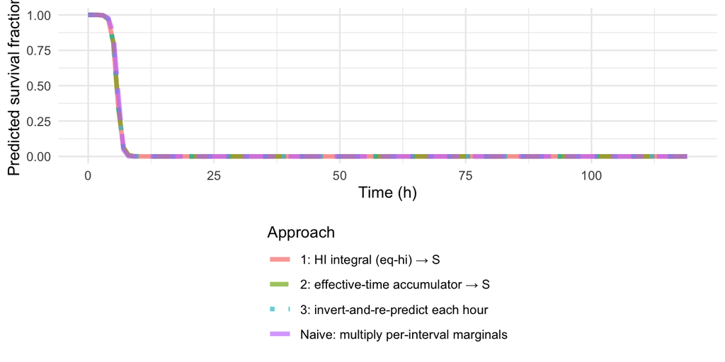

```r
df <- tibble(
  hour                                                  = hours,
  `1: HI integral (eq-hi) → S`                          = S_from_HI,
  `2: effective-time accumulator → S`                   = S_tau_eff,
  `3: invert-and-re-predict each hour`                  = S_invert,
  `Naive: multiply per-interval marginals`              = S_naive
) |>
  pivot_longer(-hour, names_to = "Approach", values_to = "S")

ggplot(df, aes(hour, S,
               colour    = Approach,
               linetype  = Approach)) +
  geom_line(linewidth = 1.5, alpha = 0.65) +
  scale_linetype_manual(values = c("solid", "dashed", "dotted", "longdash")) +
  labs(x = "Time (h)", y = "Predicted survival fraction") +
  theme_minimal(base_size = 11) +
  theme(legend.position = "bottom",
        legend.direction = "vertical")
```

## References

Jørgensen, L.B., Malte, H. & Overgaard, J. (2021). [A unifying model to estimate thermal tolerance limits in ectotherms across static, dynamic and fluctuating exposures to thermal stress](https://doi.org/10.1038/s41598-021-92004-6). *Scientific Reports*, 11, 12840.

Rezende, E.L., Bozinovic, F., Szilágyi, A. & Santos, M. (2020). [Predicting temperature mortality and selection in natural Drosophila populations](https://doi.org/10.1126/science.aba9287). *Science*, 369, 1242–1245.